# MY470 Computer Programming: The R Language

Week 8 Lecture

## Outline

1. Introduction
2. Fundamentals and data structures
3. Control flow
4. Functions
5. Reading data and plotting
6. Resources

## Outline

1. **Introduction**
2. Fundamentals and data structures
3. Control flow
4. Functions
5. Reading data and plotting
6. Resources

## To Begin With

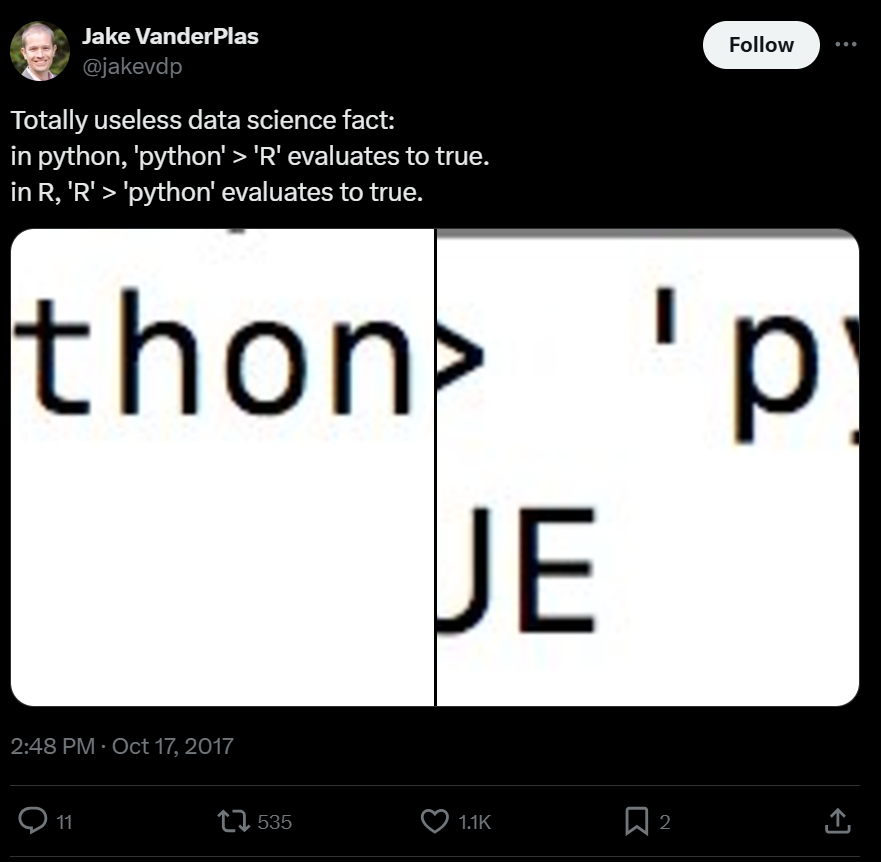

## R in a Nutshell

- Open source programming language under [GPL](https://www.gnu.org/licenses/gpl.html)
- Inspired by the programming language S
- Useful for statistics and data science, graphics, network analysis, machine learning, web scraping, general purpose programming (to a degree)…
- R has over 10,000 user contributed packages on The Comprehensive R Archive Network ([CRAN](https://cran.r-project.org/)) and many more elsewhere and in development
- Available on all platforms
- High level, object oriented, but at its core a functional language
- Interpreted — can be run interactively or as scripts, like python

## Installing R

- R 4.X.X – Install from https://www.r-project.org/
- Install any IDE (Integrated Development Environment) you prefer afterwards:
  - RStudio
  - VS Code
  - Positron

## Running R Interactively: RStudio

- The classic IDE for R, makes everything easier
- [R Markdown](https://rmarkdown.rstudio.com/) and [Quarto](https://quarto.org/) are the R equivalents to Jupyter Notebooks (Quarto is multi-language – can use both R and Python in the same document)

[figure not shown]

## Running R Interactively: VS Code

- Install the R extension in VS Code
- You may also be prompted to install an R package “languageserver”

[figure not shown]

## Running R Interactively: Positron

- A new multi-language IDE forked from VS Code by the team behind RStudio
- Combines the flexibility of VS Code with the R-specific features of RStudio

[figure not shown]

## Installing and Managing Packages in R

- What makes R particularly useful to data scientists is its community
- Over 10,000 user-contributed (and maintained) packages on CRAN and many more elsewhere
- CRAN “is a network of ftp and web servers around the world that store identical, up-to-date, versions of code and documentation for R”, see [CRAN](https://cran.r-project.org/)
- To install a package for a given R installation, run directly in R `install.packages("packagename")` (similar to `pip install` and `conda install`, which you run from the terminal, however)
- To load a package in a specific workspace, include `library("packagename")` at the beginning of your script (similar to `import`)
- Packages are the best thing about R, and also one of the more annoying things about R. Wise to invest in package management solutions early, e.g. [renv](https://rstudio.github.io/renv/articles/renv.html) or [groundhog](https://groundhogr.com/).

## Outline

1. Introduction
2. **Fundamentals and data structures**
3. Control flow
4. Functions
5. Reading in data and plotting
6. Data science workflows with R today

## Fundamentals and Data Structures

- Basic operations in R
- Objects in R
- Key data structures
  - Atomic vectors
  - Lists
  - Matrices and data frames

## Operators and Mathematical Functions

| **Python** | **R** |
| --- | --- |
| `+` | `+` |
| `-` | `-` |
| `/` | `/` |
| `*` | `*` |
| `**` | **`^`** |
| `%` | **`%%`** |
| `//` | **`%/%`** |

```r
log(<number>)
exp(<number>)
sqrt(<number>)
mean(<numbers>)
sum(<numbers>)
```

## Logical Operators

| **Python** | **R** |
| --- | --- |
| `<` | `<` |
| `>=` | `>=` |
| `==` | `==` |
| `!=` | `!=` |
| `and` | **`&`** |
| `or` | **`\|`** |
| `in` | **`%in%`** |

## Object Assignment

- The assignment operator in R is `<-`. Assigns values on the right to objects on the left.
- Can also use `=` but subtle differences. Conventionally, use `<-` for assignments, and `=` for arguments in functions.
- The `<-` notation also emphasises that `=` is not a mathematical equal sign when using it for assignments in programming, e.g.,`x = x + 1` ?

```r
my_object <- 10
print(my_object)
```

```
## [1] 10
```

```r
my_other_object <- 4
print(my_object - my_other_object)
```

```
## [1] 6
```

## Mutable/Immutable Objects

- A way to think about mutable vs immutable object is whether they are copied to a new address in memory when modified or kept in their old one
- Unlike in Python, most objects in R are copy-on-modify (with some important exceptions), so can be called immutable in that sense
- It can pay off to study these topics for performance of code regardless of the language.
- A very good summary for R, which is also the basis of this slide and the next two, can be found here: https://adv-r.hadley.nz/names-values.html

## Mutable/Immutable Objects

```r
x <- c(3, 6, 9)
x[2] <- 4
pryr::address(x)   # check memory address of x
```

```
## [1] "0x193bf1a50f8"
```

```r
y <- x
identical(pryr::address(x), pryr::address(y))
```

```
## [1] TRUE
```

## Mutable/Immutable Objects

```r
x[2] <- 4
x
```

```
## [1] 3 4 9
```

```r
identical(pryr::address(x), pryr::address(y))
```

```
## [1] FALSE
```

- Can compare this to Python using `id()`:

```python
# Mutable          # Immutable
a = [1,2,3]        b = 42
id(a)              id(b)
a[2] = 4           b += 1
id(a)              id(b)
```

## Querying Object Attributes

```r
y <- 10       # For example a numeric vector of length 1
class(y)      # Class of the object
```

```
## [1] "numeric"
```

```r
typeof(y)     # R's internal type for storage
```

```
## [1] "double"
```

```r
length(y)     # Length
```

```
## [1] 1
```

```r
attributes(y) # Metadata (matrices e.g. store their dimensions)
```

```r
names(y)      # Names
```

```r
dim(y)        # Dimensions
```

## Viewing Objects in Your Global Environment and Removing Them

- List objects in your current environment

```r
x <- 5
ls()
```

```
## [1] "my_object"       "my_other_object" "x"               "y"
```

- Remove objects from your current environment

```r
rm(x)
ls()
```

```
## [1] "my_object"       "my_other_object" "y"
```

```r
rm(list = ls())    # Remove all
```

## Common Data Structures in R

| Dimension | Stores homogenous elements | Stores heterogenous elements |
| --- | --- | --- |
| 1D | Atomic vector | **List** |
| 2D | Matrix | **Data frame** |
| nD | Array |  |

http://adv-r.had.co.nz/Data-structures.html

More extensive lists e.g. here: https://cran.r-project.org/doc/manuals/r-release/R-lang.html

## Comparison of Python and R

| **Python class** | **Closest R class** |
| --- | --- |
| bool | logical |
| int | numeric: integer |
| float | numeric: double |
| str | character |
| list | unnamed list |
| dict | named list (named vector also has key-value structure but can only store one type) |
| tuple | - |
| set | - |

## Vectors in R

- Atomic vectors
- Lists (sometimes called recursive vectors)

## Atomic vectors

- An (atomic) vector is a collection of entities which all share the same type
- Vectors are the most common and basic data structure in R

Six types (excluding `raw` and `complex` for this lecture)

- character
- integer
- double
- logical

Integer and double vectors are called numeric vectors

https://r4ds.had.co.nz/vectors.html

## Types

| Example | Type |
| --- | --- |
| `"a"`, `"swc"` | character |
| `2L` (Must add a `L` at end to denote integer) | numeric: integer |
| `2`, `15.5` | numeric: double |
| `TRUE`, `FALSE` | logical |

## Special values

- Integers have one special value: `NA`
- Doubles have four: `NA`, `NaN`, `Inf` and `-Inf`

`Inf` is infinity. You can have either positive or negative infinity

```r
1 / 0
```

```
## [1] Inf
```

`NaN` means Not a number. It is an undefined value

```r
0 / 0
```

```
## [1] NaN
```

## Examples

Use the `c()` function to concatenate observations into a vector

- Character vector

```r
char_vec <- c("hello", "world")
print(char_vec)
```

```
## [1] "hello" "world"
```

```r
num_double_vec <- c(5, 4, 100, 7.65)
print(num_double_vec)
```

```
## [1]   5.00   4.00 100.00   7.65
```

- Logical vector

```r
logical_vec <- c(TRUE, FALSE, TRUE)
print(logical_vec)
```

```
## [1]  TRUE FALSE  TRUE
```

## Everything in R Is a Vector!

- The following two objects are identical in R: scalars are vectors of length one here!

```r
identical(1.41, c(1.41))
```

```
## [1] TRUE
```

## Empty Vectors

- You can create an empty vector with `vector()` (by default the mode is `logical`, but you can define different modes as shown in the examples below)
- It is more common to use direct constructors such as `character()`, `numeric()`, etc.

```r
vector()
```

```
## logical(0)
```

```r
vector(mode = "character", length = 10) # with a length and type
```

```
##  [1] "" "" "" "" "" "" "" "" "" ""
```

```r
character(5) # character vector of length 5, also see numeric(5) and logical(5)
```

```
## [1] "" "" "" "" ""
```

## Add Elements to Vectors

```r
z <- c("my470", "is")
z <- c(z, "fantastic")
z
```

```
## [1] "my470"     "is"        "fantastic"
```

## Create Vectors with Sequences of Numbers

```r
series <- 1:10
series
```

```
##  [1]  1  2  3  4  5  6  7  8  9 10
```

```r
series <- seq(1, 10, by = 0.1)
series
```

```
##  [1]  1.0  1.1  1.2  1.3  1.4  1.5  1.6  1.7  1.8  1.9  2.0  2.1  2.2  2.3  2.4
## [16]  2.5  2.6  2.7  2.8  2.9  3.0  3.1  3.2  3.3  3.4  3.5  3.6  3.7  3.8  3.9
## [31]  4.0  4.1  4.2  4.3  4.4  4.5  4.6  4.7  4.8  4.9  5.0  5.1  5.2  5.3  5.4
## [46]  5.5  5.6  5.7  5.8  5.9  6.0  6.1  6.2  6.3  6.4  6.5  6.6  6.7  6.8  6.9
## [61]  7.0  7.1  7.2  7.3  7.4  7.5  7.6  7.7  7.8  7.9  8.0  8.1  8.2  8.3  8.4
## [76]  8.5  8.6  8.7  8.8  8.9  9.0  9.1  9.2  9.3  9.4  9.5  9.6  9.7  9.8  9.9
## [91] 10.0
```

```r
class(series)
```

```
## [1] "numeric"
```

## Index Elements

- **R indices start at 1**
- **R slices include the last element**
- So `myvector[1:3]` selects 1st, 2nd, and 3rd elements in R
- In Python, it would be `mylist[0:3]`

## Implications for Indexing Characters

- In Python:

```python
letters = "abcdefghijklmnopqrztuv"
print(letters[0:4])
```

- In R, however, even a single string is a character vector of length one
- Hence, we cannot index individual character elements of a string in R like this

```r
firstletters <- "abcdefg"
firstletters[1:4]
```

```
## [1] "abcdefg" NA        NA        NA
```

## Implications for Indexing Characters

- Instead, use specialized functions

```r
substr(firstletters, 1, 3)
```

```
## [1] "abc"
```

- To determine length of a string, e.g. use `nchar`

```r
length("London")
```

```
## [1] 1
```

```r
nchar("London")
```

```
## [1] 6
```

## Vector Subsetting in R

- To subset a `vector`, use square parenthesis to index the elements you would like via `object[index]`.
- Numerical subsetting

```r
num_double_vec[3]
```

```
## [1] 100
```

```r
num_double_vec[1:2]
```

```
## [1] 5 4
```

## Vector Subsetting in R

- Subsetting with names

```r
x <- c(1, 2, 4)
names(x) <- c("element1", "element2", "element3")
x["element1"]
```

```
## element1
##        1
```

Caveat: Although this looks somewhat like a Python dictionary, recall that vectors can only store single types

## Vector Subsetting in R

- Logical subsetting

```r
char_vec <- c("hello", "world")
char_vec
```

```
## [1] "hello" "world"
```

```r
logical_vec <- c(TRUE, FALSE)
logical_vec
```

```
## [1]  TRUE FALSE
```

```r
char_vec[logical_vec]
```

```
## [1] "hello"
```

## Vector Operations

- In R, mathematical operations on vectors typically occur **element-wise** (unless you, e.g., specify a dot-product with `%*%`)

```r
fib <- c(1, 1, 2, 3, 5, 8, 13, 21)
fib[1:7] + fib[2:8]
```

```
## [1]  2  3  5  8 13 21 34
```

- It is also possible to perform logical operations on vectors

```r
fib <- c(1, 1, 2, 3, 5, 8, 13, 21)
fib_greater_five <- fib > 5
fib_greater_five
```

```
## [1] FALSE FALSE FALSE FALSE FALSE  TRUE  TRUE  TRUE
```

## Recycling

- R usually operates on vectors of the same length
- If it encounters two vectors of different lengths in a binary operation, it *replicates* (recycles) the smaller vector until it is of the same length as the longer vector
- Afterwards it does the operation
- Related to “broadcasting” in numpy
- Often helpful, but can lead to very hard-to-find bugs

## Recycling

- If the recycled smaller vector has to be “chopped off” to make it the length of the longer vector, you will get a warning, but it will still return a result

```r
x <- c(1, 2, 3)
y <- c(5, 10)

x * y
```

```
## Warning in x * y: longer object length is not a multiple of shorter object
## length
```

```
## [1]  5 20 15
```

```r
x <- 1:20

x * c(1, 0)    # turns the even numbers to 0
```

```
##  [1]  1  0  3  0  5  0  7  0  9  0 11  0 13  0 15  0 17  0 19  0
```

## Factors: Vectors with Labels

- A factor is a special kind of vector
- It is similar to a character vector, but each unique element is also associated with a numerical value which allows to better process categorical data
- A factor vector can only contain predefined values

```r
factor_vec <- as.factor(c("a", "b", "c", "a", "b", "c"))
factor_vec
```

```
## [1] a b c a b c
## Levels: a b c
```

```r
as.numeric(factor_vec) # how it is processed in the background
```

```
## [1] 1 2 3 1 2 3
```

```r
as.character(factor_vec) # how it is displayed
```

```
## [1] "a" "b" "c" "a" "b" "c"
```

- Note: Statistical models can require variables be stored as factors

## Lists

- Lists are the other type of vector in R. They are sometimes referred to as “recursive vectors” as lists can also contain lists themselves
- In general, however, atomic vectors are commonly called `vectors` in R and lists are called `lists`
- A `list` is a collection of any set of object types
- Closest to the dictionary’s key-value structure in Python if elements in the list are named

## Lists

A `list` is a collection of any set of object types

```r
my_list <- list(something = num_double_vec,
                another_thing = matrix(data = 1:9, nrow = 3, ncol = 3),
                something_else = "my470")
my_list
```

```
## $something
## [1]   5.00   4.00 100.00   7.65
##
## $another_thing
##      [,1] [,2] [,3]
## [1,]    1    4    7
## [2,]    2    5    8
## [3,]    3    6    9
##
## $something_else
## [1] "my470"
```

## How to Index List Elements in R

- **Using [**

```r
my_list["something_else"]
```

```
## $something_else
## [1] "my470"
```

```r
my_list[3]
```

```
## $something_else
## [1] "my470"
```

```r
class(my_list[3])
```

```
## [1] "list"
```

## How to Index List Elements in R

- **Using [[**

```r
my_list[["something"]]
```

```
## [1]   5.00   4.00 100.00   7.65
```

```r
my_list[[1]]
```

```
## [1]   5.00   4.00 100.00   7.65
```

```r
class(my_list[[1]])
```

```
## [1] "numeric"
```

## How to Index List Elements in R

- **Using $**

```r
my_list$another_thing
```

```
##      [,1] [,2] [,3]
## [1,]    1    4    7
## [2,]    2    5    8
## [3,]    3    6    9
```

(does not allow multiple elements to be indexed in one command)

## Matrices

- Now let’s turn to tabular data
- A `matrix` arranges data from a vector into a tabular form, **all elements have to be of the same type**
- `Arrays` have more than 2 dimensions

```r
my_matrix <- matrix(data = 1:100, nrow = 10, ncol = 10)
my_matrix
```

```
##       [,1] [,2] [,3] [,4] [,5] [,6] [,7] [,8] [,9] [,10]
##  [1,]    1   11   21   31   41   51   61   71   81    91
##  [2,]    2   12   22   32   42   52   62   72   82    92
##  [3,]    3   13   23   33   43   53   63   73   83    93
##  [4,]    4   14   24   34   44   54   64   74   84    94
##  [5,]    5   15   25   35   45   55   65   75   85    95
##  [6,]    6   16   26   36   46   56   66   76   86    96
##  [7,]    7   17   27   37   47   57   67   77   87    97
##  [8,]    8   18   28   38   48   58   68   78   88    98
##  [9,]    9   19   29   39   49   59   69   79   89    99
## [10,]   10   20   30   40   50   60   70   80   90   100
```

## Data Frames

A `data.frame`, in contrast, is a matrix-like R object in which the **columns can be of different types**

```r
my_data_frame <- data.frame(numbers = num_double_vec,
                            words = char_vec,
                            logical = logical_vec)
my_data_frame
```

```
##   numbers words logical
## 1    5.00 hello    TRUE
## 2    4.00 world   FALSE
## 3  100.00 hello    TRUE
## 4    7.65 world   FALSE
```

## Matrix and Data Frame Subsetting

- You can subset a `matrix` or `data.frame` with integers referring to [rows, columns]

```r
my_matrix[2, 2]
```

```
## [1] 12
```

```r
my_matrix[2:3, 2:3]
```

```
##      [,1] [,2]
## [1,]   12   22
## [2,]   13   23
```

```r
my_data_frame[, 1]
```

```
## [1]   5.00   4.00 100.00   7.65
```

## Matrix and Data Frame Subsetting

- You can also access rows and columns with names

```r
# Adding some column names to the matrix
colnames(my_matrix) = letters[1:10]

# Works for matrices and data frames with column names
my_matrix[, "e"]
```

```
##  [1] 41 42 43 44 45 46 47 48 49 50
```

```r
my_data_frame[, "numbers"]
```

```
## [1]   5.00   4.00 100.00   7.65
```

```r
my_data_frame[, c("numbers", "words")]
```

```
##   numbers words
## 1    5.00 hello
## 2    4.00 world
## 3  100.00 hello
## 4    7.65 world
```

```r
# Works only with data frame columns
my_data_frame$numbers
```

```
## [1]   5.00   4.00 100.00   7.65
```

## Matrix and Data Frame Subsetting

- Dropping rows or columns can be done using the `-` operator and integers (in combination with the `c` function if multiple rows are dropped)

```r
my_matrix[-4, -5]
```

```
##        a  b  c  d  f  g  h  i   j
##  [1,]  1 11 21 31 51 61 71 81  91
##  [2,]  2 12 22 32 52 62 72 82  92
##  [3,]  3 13 23 33 53 63 73 83  93
##  [4,]  5 15 25 35 55 65 75 85  95
##  [5,]  6 16 26 36 56 66 76 86  96
##  [6,]  7 17 27 37 57 67 77 87  97
##  [7,]  8 18 28 38 58 68 78 88  98
##  [8,]  9 19 29 39 59 69 79 89  99
##  [9,] 10 20 30 40 60 70 80 90 100
```

```r
my_matrix[-c(2:8), -c(2:8)]
```

```
##       a  i   j
## [1,]  1 81  91
## [2,]  9 89  99
## [3,] 10 90 100
```

- `2:8` creates a vector of the integers 2, … , 8 and the `-` operator negates these. We wrap the vector in the `c` function so that `-` applies to each element, and not just the first

## Outline

1. Introduction
2. Fundamentals and data structures
3. **Control flow**
4. Functions
5. Reading in data and plotting
6. Data science workflows with R today

## If-Else Statements

- Using the logical operations discussed before, R has the usual if, if-else, and else conditions
- Contrary to Python, indentation is optional (but advised for readability), and brackets separate parts of the statements

```r
x <- 3
if (x > 4) {
  print(24)
} else {
  print(17)
}
```

```
## [1] 17
```

## With an Additional `else if` Part

```r
x <- 2
y <- 3
if (x < y) {
    print(24)
} else if (x > y) {
    print(18)
} else {
    print(17)
}
```

```
## [1] 24
```

## For-Loops

- Like conditionals, the different parts of loops are distinguished via brackets rather than mandatory indentation

```r
for (i in 1:4) {
    print(i)
}
```

```
## [1] 1
## [1] 2
## [1] 3
## [1] 4
```

```r
character_vector <- c("hello", "world")
for (text in character_vector) {
    print(text)
}
```

```
## [1] "hello"
## [1] "world"
```

## While-Loops

```r
x <- 1
while (x < 5) {
    print(x)
    x <- x + 1
}
```

```
## [1] 1
## [1] 2
## [1] 3
## [1] 4
```

## Improving Efficiency

- Using vectorised operations where possible instead of loops can immensely speed up your code

```r
# For example:
x <- 1:1000
y <- 1:1000
z <- numeric(1000)
for (i in 1:1000) {
  z[i] <- x[i]*y[i]
}
# vs:
z <- x*y

# Or:
z <- 0
for (i in 1:1000) {
  z <- z + x[i]*y[i]
}
# vs:
z <- x%*%y
```

- Same considerations apply to vectorised operations in `numpy`
- For an in-depth discussion of measuring and improving performance in R: https://adv-r.hadley.nz/perf-measure.html and https://adv-r.hadley.nz/perf-improve.html

## Outline

1. Introduction
2. Fundamentals and data structures
3. Control flow
4. **Functions**
5. Reading in data and plotting
6. Data science workflows with R today

## Calling Functions

```r
function_name(parameter_one, prameter_two, ...)
```

- When a function parameter is not assigned a default value, then it is mandatory to be specified by the user
- Default arguments can be overridden if supplied
- For example, consider the `mean()` function: `mean(x, na.rm = FALSE)`
- This function takes two (main) arguments
  - `x` is a numeric vector
  - `na.rm` is a logical value that indicates whether we’d like to remove missing values (`NA`). `na.rm` is set to `FALSE` by default

```r
vec <- c(1, 2, 3, NA, 5)
mean(x = vec) # returns NA
```

```
## [1] NA
```

```r
mean(x = vec, na.rm = TRUE) # this gives us what we're after
```

```
## [1] 2.75
```

## Defining Functions

- Just like in Python and other programming languages, it is key to create own functions for a modular programme

```r
my_addition_function <- function(a = 10, b) {
    return(a + b)
}

my_addition_function(a = 5, b = 50)
```

```
## [1] 55
```

```r
my_addition_function(3, 4)
```

```
## [1] 7
```

```r
my_addition_function(b = 100)
```

```
## [1] 110
```

- Notice that, in R, default parameters can come before non-default ones; this is not the case in Python

## Variables in Functions Have Local Scope

```r
my_demo_function <- function(a) {
    a <- a * 2
    return(a)
}

a <- 1
my_demo_function(a = 20)
```

```
## [1] 40
```

```r
a
```

```
## [1] 1
```

## But Functions Can Access Out-of-Scope Variables

```r
a <- 1

my_demo_function <- function() {
    a <- a * 2
    return(a)
}

my_demo_function()
```

```
## [1] 2
```

## The Pipe Operator

- Very often used in R code today either as `|>` from base R or `%>%` from the `magrittr` package
- The pipe operator indicates that the previous object is used as the first argument in the subsequent function

```r
x <- c(1,2,3,4,15)
mean(x)
```

```
## [1] 5
```

```r
# Same but with the pipe operator
x |> mean()
```

```
## [1] 5
```

```r
# And with the tidyverse/magrittr pipe
x %>% mean()
```

```
## [1] 5
```

## The Pipe Operator

- Useful for chains of computations

```r
x <- c("1", "2")
x %>%
  as.numeric() %>%
  mean() %>%
  sqrt()
```

```
## [1] 1.224745
```

```r
# Easier to read than the equivalent nested functions
sqrt(mean(as.numeric(x)))
```

```
## [1] 1.224745
```

## Loops Revisited: Apply Functions

- Another very frequently used approach in R is to replace loops with `apply`
- It applies a function to every column, row, element of a vector, list, etc.
- Apply exists in Python too, for example `map()` or `df.apply()` in `pandas`
- The following function avoids having to write a loop over all columns and determining the maximum value in each of them

```r
x <- matrix(1:9, nrow = 3, ncol = 3)
x
```

```
##      [,1] [,2] [,3]
## [1,]    1    4    7
## [2,]    2    5    8
## [3,]    3    6    9
```

```r
apply(X = x, MARGIN = 2, FUN = max)
```

```
## [1] 3 6 9
```

- Other options
  - `sapply` to apply function to every element of a vector
  - `lapply` to apply function to every element of list

## The Procedural Programming Paradigm

A “programming paradigm” refers to a standard practice or perspective on programming (how you **think about** or **approach a problem**).

Python at its core follows the procedural programming paradigm:

- Think of programming like a recipe
- You give specific instructions on what to do and how to do it
- You have a **global state** that you are modifying

You think about how things are changing over time rather that what methods you are calling to get the result you want.

## The Functional Programming Paradigm

R is at its core a functional programming language:

- Functions are **first-class objects** and can be:
  - Passed to other functions as parameters
  - Returned by other functions as output
  - Stored in data structures (functions are **first class* objects)
- Functions are (should be) **pure**:
  - Functions are deterministic and always produce the same output for the same input (set the random seed for stochastic process)
  - Functions have no side effects (e.g. modify arguments, modify global variables, print)
  - Variables and data are immutable

Source: https://adv-r.hadley.nz/fp.html

## Object Oriented Programming in R

- “Everything that exists in R is an object” (John Chambers)
- However, **object oriented programming (OOP)** is much less important in the daily use of R than functional programming
- OOP is more challenging in R as there are multiple OOP systems called S3, R6, S4, etc.
- If you would like to learn about object oriented programming in R (e.g. to write packages), see [here](https://adv-r.hadley.nz/oo.html)

## Functional Programming: Pros and Cons

- Advantages
  - Code is easier to understand
  - Code is easier to test and debug
  - FP is needed to implement concurrency/parallelism
- Disadvantages
  - Pure functions and recursion can be difficult to understand
  - Immutable values and recursion can decrease performance
  - Immutable values require large memory space

## Functional Programming: Pros and Cons

[figure not shown]

Source: https://xkcd.com/1790/

## R vs. Python

- Python, following more the OOP approach, has many methods and attributes attached to objects (recall week 5 on classes)
- For example, consider `R` vs. `pandas` in Python. Let’s assume we have some data contained in a data frame object called “df”
- `colnames(df)` vs. `df.columns`
- `nrow(df)` vs. `df.shape[0]`
- `apply(X = df, MARGIN = 2, FUN = max)` vs. `df.apply(func=max, axis=0)`
- Python also tends to be more procedural (modifying the global state or mutable objects)

## Outline

1. Introduction
2. Fundamentals and data structures
3. Control flow
4. Functions
5. **Reading in data and plotting**
6. Data science workflows with R today

## Reading and Writing .csv Files

```r
my_data <- read.csv(file = "my_file.csv")
```

- `my_data` is an R data.frame object
- `my_file.csv` is a .csv file with your data
- Might need to use the `stringsAsFactors = FALSE` argument
- In order for R to load `my_file.csv`, it will have to be saved in your current working directory
  - Use `getwd()` to check your current working directory
  - Use `setwd()` to change your current working directory
- Otherwise define the full path to the file

```r
write.csv(my_data, "my_file.csv")
```

## Creating (Pseudo-)Random Data

```r
set.seed(123)     # set random seed to get replicable results
n <- 1000
x <- rnorm(n)     # draw 1000 points from the normal distribution
z <- runif(n)     # draw 1000 points from the uniform distribution
g <- sample(letters[1:6], n, replace = T)   # sample with replacement
# Set some parameters, including noise
beta1 <- 0.5
beta2 <- 0.3
beta3 <- -0.4
alpha <- 0.3
eps <- rnorm(n, sd = 1)
# Generate data that follows a linear trend
y <- alpha + beta1 * x + beta2 * z + beta3 * (x * z) + eps
# Save data in a data frame
my_data <- data.frame(x = x, y = y, z = z, g = g)
```

## Plots

- Plots are one of the strengths of R
- There are two main frameworks for plotting
  1. Base R graphics
  2. `ggplot2`

## Base R Plots

- The basic plotting syntax is very simple
- `plot(x, y)` will give you a scatter plot

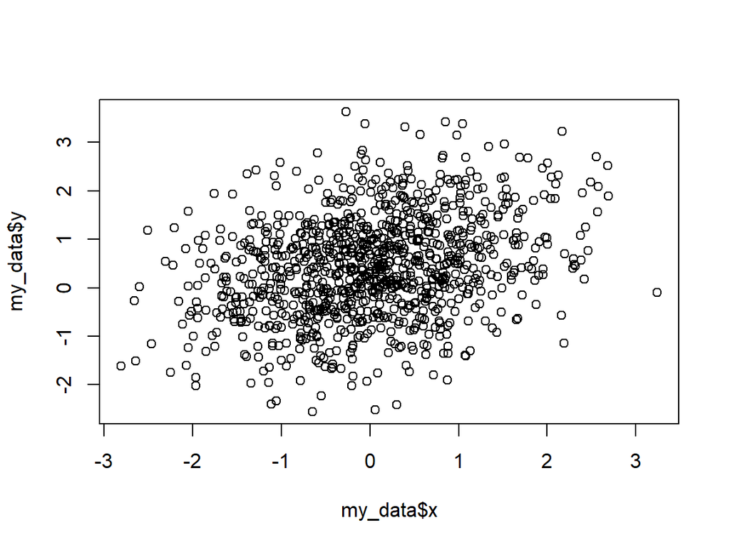

```r
plot(my_data$x, my_data$y)
```

## Improving Base R Plots

- The plot function takes a number of arguments (`?plot` for a full list)

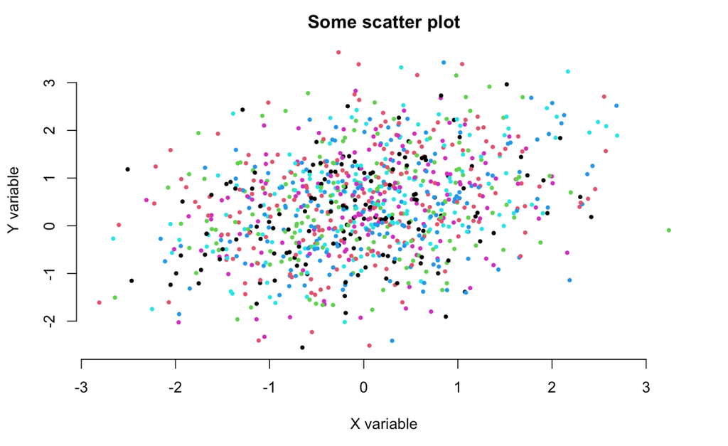

```r
plot(x = my_data$x, y = my_data$y,
     xlab = "X variable",            # x axis label
     ylab = "Y variable",            # y axis label
     main = "Some scatter plot",     # main title
     pch = 19,                       # solid points
     cex = 0.5,                      # smaller points
     bty = "n",                      # remove surrounding box
     col = as.factor(my_data$g)      # colour by grouping variable
)
```

## Visualisation with R: `ggplot2`

- `ggplot2` is a flexible tool for visualisation

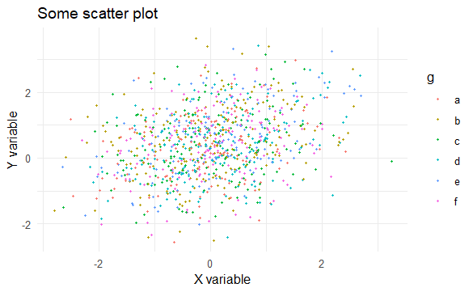

```r
ggplot2::ggplot(my_data, aes(x = x, y = y, color = as.factor(g))) +
  geom_point(size = 0.5) +
  labs(
    x = "X variable",
    y = "Y variable",
    title = "Some scatter plot",
    color = "g"
  ) +
  theme_minimal()
```

## Grammar of Graphics \(\leftrightarrow\) `{ggplot2}`

- A visualisation is a **mapping** of **data** to **aesthetics** via visual **geometries** to produce meaning.
- Formally this can be represented as a “**grammar of graphics**” (Wilkinson, 2005).
- In `{ggplot2}`, three key pieces:
  - **Data**: The information
  - **Mapping**: Correspondence between data and aesthetics (`aes()`)
  - **Layers**: Geometry and transformation (e.g. `geom_point()`, `geom_smooth()`)
- Book by Hadley Wickham, Danielle Navarro, and Thomas Lin Pedersen: https://ggplot2-book.org
- Great website with `ggplot2` sample code for many different types of plots: https://www.r-graph-gallery.com/ggplot2-package.html

## Outline

1. Introduction
2. Fundamentals and data structures
3. Control flow
4. Functions
5. Reading in data and plotting
6. **Data science workflows with R today**

## Data Science with R

- MY470 is a course about programming, so we only covered fundamentals of the R language in this lecture
- This provided the necessary knowledge for you to use a range of tools in subsequent work
- The following gives an outlook and many links to resources that you can use

## Data Processing with R

- `tidyverse`: Collection of packages such as `tidyr`, `dyplr`, `ggplot2`, etc.
  - More information: https://www.tidyverse.org/
  - “The tidyverse is an opinionated collection of R packages designed for data science. All packages share an underlying design philosophy, grammar, and data structures.”
  - Summary of how to use the `tidyverse` packages in *R for Data Science*: https://r4ds.had.co.nz/
- `data.table`: Particularly fast package to process very large datasets

## Regression with R

- Most regressions can be handled with `lm()` function for linear regression, `glm()` for generalised linear models
- However, many improvements are possible (this is an incomplete list):
  - `estimatr` for regression with robust standard errors: https://declaredesign.org/r/estimatr/
  - `fixest` for fixed effects regression: https://lrberge.github.io/fixest/
  - `lme4` for mixed effects models: https://github.com/lme4/lme4
  - `broom` for tidying up regression output: https://broom.tidymodels.org/
  - `modelsummary` for regression output and interpretation: https://vincentarelbundock.github.io/modelsummary/

## Statistical Machine Learning with R

- Range of packages from LASSO regressions (`glmnet`) to random forest (`randomForest`) or support vector machines (`e1071`)
- Excellent book that describes most key concepts in statistical machine learning: http://faculty.marshall.usc.edu/gareth-james/ISL/

- LSE course **MY474 Applied Machine Learning for Social Science**

## Text Analysis with R

- The `quanteda` package
  - Quickstart: https://quanteda.io/articles/quickstart.html
  - Tutorials: https://tutorials.quanteda.io/
- LSE course **MY459 Quantitative Text Analysis**

## Network Analysis

- Packages such as `igraph`
- Book by Douglas A. Luke: https://www.springer.com/de/book/9783319238821
- LSE course **MY461 Social Network Analysis**

## Causal Inference

- Diff-in-diff:
  - `fect`: https://yiqingxu.org/packages/fect/index.html
  - `did`: https://bcallaway11.github.io/did/
  - `synthdid`: https://synth-inference.github.io/synthdid/
- Regression discontinuity:
  - `rdrobust`: https://rdpackages.github.io/rdrobust/
- Instrumental variables:
  - `ivreg`: https://cran.r-project.org/web/packages/ivreg/vignettes/ivreg.html
- LSE course **MY457 Causal Inference in Experimental and Observational Settings**

## Excellent Books on the R Language

- Programming in R programming
  - *An Introduction to R* by Douglas et al: https://intro2r.com/
  - *Advanced R* by Hadley Wickham: https://adv-r.hadley.nz/
- Applied data science in R
  - *R for Data Science* by Hadley Wickham and Garrett Grolemund: https://r4ds.had.co.nz/
- Reproducible data science in R
  - *Building Reproducible Analytical Pipelines with R* by Bruno Rodrigues: https://raps-with-r.dev/